# crystal_molecules-solvent_molecules

```python
import pandas as pd
import numpy as np
import matplotlib.pyplot as plt
import matplotlib as mpl
import seaborn as sns

%matplotlib inline
```

```python
sns.set_context('talk')
```

```python
from statsmodels.sandbox.stats.multicomp import multipletests
from scipy.stats import pearsonr, spearmanr
```

```python
df = pd.read_csv('crystal_molecule-solvent_descriptors_delta.txt', sep='\t', index_col=0)
```

Рассмотрим подвыборку пар полиморфов, для которых различия в конформации молекул в кристалле, выраженные в значении среднеквадратичного отклонения атомных позиций (RMSD), относительно невелики: RMSD < 0.375Å

```python
correlation_df = df.query('RMSD < 0.375')
```

```python
start = 4
N = 12
correlation_df.columns[start:N]
```

```
Index(['FPSA1', 'FPSA2_solute', 'FPSA3_solute', 'FPSA4', 'FPSA5_solute',
       'RPSA_solute', 'Energy, H', 'Dipole, D'],
      dtype='object')
```

```python
correlation_df.shape
```

```
(190, 74)
```

Рассчитаем значения пирсоновкой корреляции для 8х62 = 496 пар разностей дескрипторов молекулы в кристалле - молекула растворителя

```python
%%time

res = []

for cryst_desc_column in correlation_df.columns[start:N]:
    for solv_desc_column in correlation_df.columns[N:]:

        cdf = correlation_df[[solv_desc_column, cryst_desc_column]].dropna()

        solvent = cdf[solv_desc_column]
        crystal = cdf[cryst_desc_column]

        r, p_val = pearsonr(crystal, solvent)
        res.append([cryst_desc_column, solv_desc_column, cdf.shape[0], r, p_val])
```

```
Wall time: 910 ms
```

```python
corr_df = pd.DataFrame(res, columns=['crystal molecule desc', 'solvent desc', 'N', 'Pearsons r', 'p_value'])
rejected, p_corr, _, _ = multipletests(corr_df['p_value'], alpha = 0.1, method = 'bonferroni')

corr_df['p_value_corr'] = p_corr
corr_df['rejected'] = rejected
```

```python
corr_df.sort_values(by=['p_value', 'p_value_corr'], ascending=True).head(10)
```

|  | crystal molecule desc | solvent desc | N | Pearsons r | p_value | p_value_corr | rejected |
| --- | --- | --- | --- | --- | --- | --- | --- |
| 396 | Energy, H | RNCS | 160 | 0.324575 | 0.000028 | 0.014 | True |
| 328 | RPSA_solute | NHOHCount | 190 | -0.213157 | 0.003149 | 1.000 | False |
| 488 | Dipole, D | Freezing point, oC | 160 | -0.221830 | 0.004815 | 1.000 | False |
| 357 | RPSA_solute | a1 | 188 | -0.199835 | 0.005968 | 1.000 | False |
| 346 | RPSA_solute | Acidity SA | 188 | -0.194782 | 0.007393 | 1.000 | False |
| 243 | FPSA4 | thermal conductivity, W*m-1*K-1 | 189 | 0.193572 | 0.007612 | 1.000 | False |
| 349 | RPSA_solute | AN, n_Hexane_reference | 189 | -0.193487 | 0.007639 | 1.000 | False |
| 314 | RPSA_solute | ETA_dEpsilon_D | 190 | -0.191792 | 0.008028 | 1.000 | False |
| 190 | FPSA4 | ETA_dEpsilon_D | 190 | 0.191761 | 0.008039 | 1.000 | False |
| 334 | RPSA_solute | RNCS | 190 | -0.185000 | 0.010609 | 1.000 | False |

```python
dist = []
dist.append(corr_df['Pearsons r'].values)
```

Рассчитаем значения ранговой корреляции Спирмена для 8х62 = 496 пар разностей дескрипторов молекулы в кристалле - молекула растворителя

```python
%%time
res = []

for cryst_desc_column in correlation_df.columns[start:N]:
    for solv_desc_column in correlation_df.columns[N:]:

        cdf = correlation_df[[solv_desc_column, cryst_desc_column]].dropna()

        solvent = cdf[solv_desc_column]
        crystal = cdf[cryst_desc_column]

        r, p_val = spearmanr(crystal, solvent)
        res.append([cryst_desc_column, solv_desc_column, cdf.shape[0], r, p_val])
```

```
Wall time: 1.27 s
```

```python
corr_df = pd.DataFrame(res, columns=['crystal molecule desc', 'solvent desc', 'N',  'Spearmans rho', 'p_value'])
rejected, p_corr, _, _ = multipletests(corr_df['p_value'], alpha = 0.1, method = 'bonferroni')

corr_df['p_value_corr'] = p_corr
corr_df['rejected'] = rejected
```

```python
corr_df.sort_values(by=['p_value', 'p_value_corr'], ascending=True).head(10)
```

|  | crystal molecule desc | solvent desc | N | Spearmans rho | p_value | p_value_corr | rejected |
| --- | --- | --- | --- | --- | --- | --- | --- |
| 328 | RPSA_solute | NHOHCount | 190 | -0.223932 | 0.001897 | 0.941032 | False |
| 266 | FPSA5_solute | NHOHCount | 190 | 0.200479 | 0.005548 | 1.000000 | False |
| 204 | FPSA4 | NHOHCount | 190 | 0.200430 | 0.005559 | 1.000000 | False |
| 299 | FPSA5_solute | HSP_h | 188 | 0.195174 | 0.007273 | 1.000000 | False |
| 237 | FPSA4 | HSP_h | 188 | 0.194927 | 0.007348 | 1.000000 | False |
| 222 | FPSA4 | Acidity SA | 188 | 0.192819 | 0.008023 | 1.000000 | False |
| 190 | FPSA4 | ETA_dEpsilon_D | 190 | 0.191693 | 0.008061 | 1.000000 | False |
| 252 | FPSA5_solute | ETA_dEpsilon_D | 190 | 0.190852 | 0.008349 | 1.000000 | False |
| 314 | RPSA_solute | ETA_dEpsilon_D | 190 | -0.190823 | 0.008358 | 1.000000 | False |
| 361 | RPSA_solute | HSP_h | 188 | -0.191382 | 0.008514 | 1.000000 | False |

Видим, что ни для одной из пар разностей дескрипторов достигаемый уровень значимости величины коэфициента корреляции Спирмена не ниже 0.05, что говорит об отсутствии статистической значимости найденных корреляций

```python
dist.append(corr_df['Spearmans rho'].values)
```

```python
dist_df = pd.DataFrame(dist, index=[r'$r$', r'$\rho$']).T
```

Покажем гистограммы рассчитанных коэффициентов корреляции Пирсона (слева) и Спирмена (справа) между 496 парами значений разностей дескрипторов (descriptor differences), описывающих молекулы в кристалле и молекулы растворителя

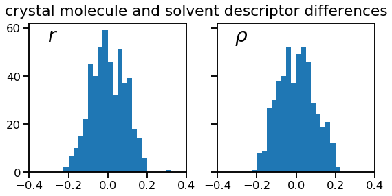

```python
fig, ax = plt.subplots(nrows=1, ncols=2, figsize=(9, 4), sharey=True)

bins=np.arange(-0.4, 0.4, 0.025)

ax[0].hist(dist_df[r'$r$'], bins=bins)
ax[0].set_xlim(-0.4, 0.4)
ax[0].set_title(r'$r$', x=0.15, y=0.85, fontsize=28)
ax[1].hist(dist_df[r'$\rho$'], bins=bins)
ax[1].set_xlim(-0.4, 0.4)
ax[1].set_title(r'$\rho$', x=0.15, y=0.85, fontsize=28)
fig.suptitle('crystal molecule and solvent descriptor differences', y=.975)
```

Как видим, коэффициенты корреляции Спирмена в целом невелики, и ни один из них не превышает 0.25 по абсолютной величине

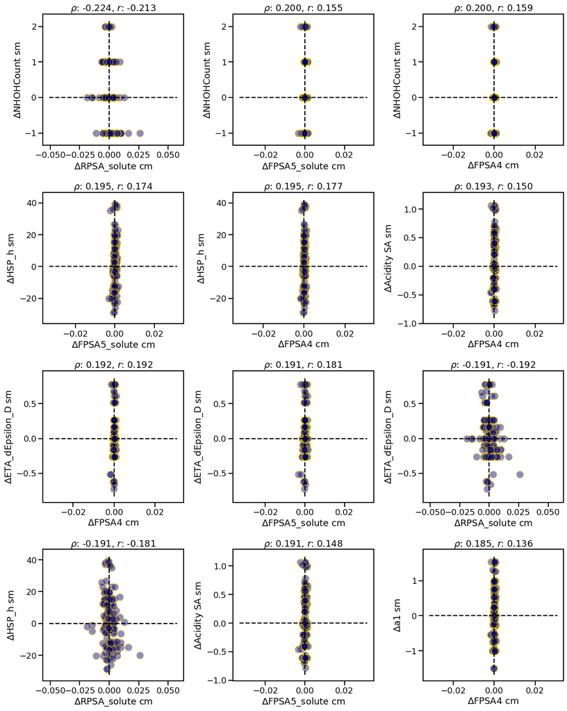

```python
N = 12
fig, ax = plt.subplots(nrows=4, ncols=3, figsize=(16, 20))

for i, (_, (d1, d2)) in enumerate(corr_df.sort_values(by=['p_value_corr', 'p_value'], ascending=True).head(N)[['crystal molecule desc', 'solvent desc']].iterrows()):
    axis = ax[i//3, i%3]

    c_df = correlation_df[[d1, d2]].dropna()

    axis.scatter(c_df[d1], c_df[d2], s=200, alpha=.45, color='navy', edgecolor='gold')
    axis.hlines(0, *axis.get_xlim(), colors='k', linestyles='dashed')
    axis.vlines(0, *axis.get_ylim(), colors='k', linestyles='dashed')

    axis.set_title(r'$\rho$: {:.3f}, $r$: {:.3f}'.format(spearmanr(c_df[d1], c_df[d2])[0],
                                                         pearsonr(c_df[d1], c_df[d2])[0]))
    axis.set_xlabel(r'$\Delta$' + d1.replace('_mol', ''))
    axis.set_ylabel(r'$\Delta$' + d2)

fig.tight_layout()
```

Более подробное описание и обсуждение полученных результатов статистического анализа представлено в статье [On the Influence of Solvent Properties on the Structural Characteristics of Molecular Crystal Polymorphs, Cryst. Growth Des. 2020, 20, 11, 7152–7162](https://pubs.acs.org/doi/10.1021/acs.cgd.0c00753)